# Vienna Urban Heat Island, 2005-2025: A Six-Station, Three-LCZ Analysis – Final Report with Integrated Pipeline

Group 2

Andrei Lucian Strachinaru (12543617)

Hovhanniyan Norayr (12104935)

Leon Lehmann (12020654)

2026-05-31

# Abstract

This study quantifies the Vienna Urban Heat Island (UHI) over 2005-2025 using a six-station network of GeoSphere Austria stations, three urban and three rural, spanning four Local Climate Zones (Stewart & Oke, 2012). Daily and hourly records were preprocessed, all nine urban-rural pairwise temperature differences (ΔT) were derived, an *ideal-night* filter (calm/clear/dry) selected the 1 606 nights most diagnostic of urban morphology, the Climatol package was applied for breakpoint detection (Guijarro, 2018), and seasonal Mann-Kendall and Sen’s slope tests quantified trends. The headline result is an Innere Stadt - Groß-Enzersdorf ideal-night ΔT_min of **+0.99 °C** with an all-night annual mean intensifying at **+0.011 °C yr⁻¹** (p < 0.001), consistent with the magnitudes reported by (Böhm, 1998) and (Žuvela-Aloise et al., 2016) for Vienna and with the European pattern documented by (Bassani et al., 2022).

# 1. Introduction

The urban heat island is the systematic temperature excess of urban over surrounding rural areas, driven by anthropogenic heat release, the heat capacity of impervious surfaces, reduced evapotranspiration, and the urban geometry’s modification of the radiation balance (Oke, 1982); (Stewart & Oke, 2012). For Vienna, the seminal work of (Böhm, 1998) homogenised 34 candidate series over 1951-1995 and reported urban-excess magnitudes from 0.2 °C in suburbs to 1.6 °C in the densest blocks, with the *trend* in urban excess itself reaching 0.6 °C over 45 years even while the city’s population stayed essentially flat – driven instead by floor-space expansion, traffic-area growth, and the loss of green space.

This report applies a modernised version of that workflow to the 2005-2025 window. Six stations are analysed in parallel, producing nine urban-rural pair series, an ideal-night filter (Oke, 1982), an LCZ-stratified framing (Hammerberg et al., 2018), and a trend assessment using non-parametric tests appropriate for autocorrelated environmental series (Kendall, 1975); (Sen, 1968); (Pettitt, 1979); (Hirsch & Slack, 1984). Homogenisation uses the Climatol package (Guijarro, 2018), which implements the SNHT (Alexandersson, 1986) in a pairwise framework.

# 2. Data and methods

## 2.1 Station network

Six GeoSphere Austria stations were used, with TAWES IDs verified against `gs_metadata()` for the `klima-v2-1d` and `klima-v2-1h` resources (Table 1). The three urban stations are **Wien Innere Stadt (IS, ID 5904)**, **Wien Hohe Warte (HW, ID 5925)**, and **Wien Unterlaa (UL, ID 107)**. The three rural references are **Groß-Enzersdorf (GE, ID 31)** in the agricultural Marchfeld plain to the east, **Langenlebarn (LL, ID 51)** in the Danube valley to the west, and **Wien Mariabrunn (MB, ID 106)** at the forested western edge. Hourly cloud cover comes from the Hohe Warte SYNOP record (WMO ID 11035, resource `synop-v1-1h`). LCZ classifications follow (Hammerberg et al., 2018). The geographic layout is shown in Figure 1.

**Table 1.** Six active stations. TAWES IDs valid for klima-v2 resources; LCZ from Hammerberg et al. (2018).

| Short | Name | ID | Lon | Lat | Alt (m) | Role | LCZ |
| --- | --- | --- | --- | --- | --- | --- | --- |
| IS | Wien Innere Stadt | 5904 | 16.371 | 48.198 | 177 | urban | 2 |
| HW | Wien Hohe Warte | 5925 | 16.357 | 48.249 | 198 | urban | 6 |
| UL | Wien Unterlaa | 107 | 16.419 | 48.125 | 200 | urban | 9/D |
| GE | Gross-Enzersdorf | 31 | 16.559 | 48.200 | 154 | rural | D |
| LL | Langenlebarn | 51 | 16.118 | 48.324 | 175 | rural | D |
| MB | Wien Mariabrunn | 106 | 16.229 | 48.207 | 225 | rural | A/B |

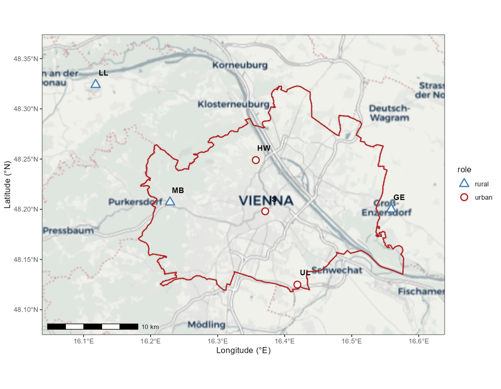

Station network across the Vienna basin on an OSM cartolight basemap. Urban stations are red circles, rural references blue triangles. The Vienna municipal boundary is overlaid in red. Land-surface types are visible from the OSM rendering: dense built-up areas in grey, forest in green, the Danube and oxbow lakes in blue, and farmland in beige. Generated by src/annex1_station_map.R.

## 2.2 Data acquisition and preprocessing

Daily (`klima-v2-1d`) and hourly (`klima-v2-1h`) records were downloaded for 2005-01-01 to 2025-12-31 using the `gsdata` R package (Stauffer, 2024). Two data-quality issues required attention before any analysis. First, the GeoSphere daily precipitation field `rr` uses **-1 as a sentinel for “trace precipitation”** (German *Spuren*) – present on 42-61 % of rows per station. Step 4 of `src/02_preprocess.R` converts `-1` to `NA` so sums and means are not contaminated. Second, the hourly datetime column mixes full timestamps with date-only strings on the first row of each day, and the `as.POSIXct(..., tryFormats = ...)` parser silently collapses every hourly row to 00:00 UTC; a two-pass parser was implemented to restore correct hourly indexing.

## 2.3 Parameters and units

Table 2 lists every GeoSphere parameter used in this study, along with its physical meaning and unit. Parameter naming follows the GeoSphere `klima-v2` schema; SYNOP parameters (`N`, `T`, `Td`) follow the WMO Manual on Codes.

**Table 2.** GeoSphere parameters with units and how each is used in the pipeline.

| Code | Resource | Description | Unit | Used in |
| --- | --- | --- | --- | --- |
| tl_mittel | klima-v2-1d | Daily mean air temperature | °C | ΔT series, annual means |
| tlmax | klima-v2-1d | Daily maximum air temperature | °C | summer/hot-day counts |
| tlmin | klima-v2-1d | Daily minimum air temperature | °C | tropical nights, ideal-night ΔT_min |
| tl_i / tl_ii / tl_iii | klima-v2-1d | Air T at 07/14/19 CET obs terms | °C | QC cross-check |
| rf_mittel | klima-v2-1d | Daily mean relative humidity | % | QC, humidity analysis |
| rf_i / rf_ii / rf_iii | klima-v2-1d | RH at 07/14/19 CET | % | QC |
| dampf_mittel | klima-v2-1d | Daily mean water-vapour pressure | hPa | QC |
| vv_mittel | klima-v2-1d | Daily mean wind speed | m s⁻¹ | daily wind QC |
| ffx | klima-v2-1d | Daily maximum wind gust | m s⁻¹ | daily gust QC |
| ff | klima-v2-1h | Hourly mean wind speed | m s⁻¹ | ideal-night wind criterion (HW) |
| bewm_mittel | klima-v2-1d | Daily mean cloud cover (manual obs) | % (0-100) | alternative cloud reference |
| rr | klima-v2-1d/1h | Precipitation (daily total or hourly inc.) | mm | ideal-night dry criterion (HW) |
| so_h | klima-v2-1d/1h | Sunshine duration | hours | daily QC |
| cglo_j | klima-v2-1d | Daily total global radiation | J cm⁻² | daily radiation QC |
| cglo | klima-v2-1h | Hourly global radiation | J cm⁻² | hourly QC |
| p_mittel | klima-v2-1d | Daily mean station-level air pressure | hPa | daily pressure QC |
| tl | klima-v2-1h | Hourly air temperature | °C | hourly T QC |
| N | synop-v1-1h | Total cloud cover (SYNOP) | oktas 0-8 | ideal-night cloud criterion (HW SYNOP) |
| T | synop-v1-1h | Air temperature (SYNOP) | °C | SYNOP T cross-check vs klima tl |
| Td | synop-v1-1h | Dew-point temperature (SYNOP) | °C | humidity cross-check |

## 2.4 Derived indicators

`src/03_indicators.R` computes per-station daily DTR (`tlmax - tlmin`), the nine pairwise daily ΔT series ($\Delta T = T_\text{urban} - T_\text{rural}$ for $T \in \{\text{Tmean, Tmax, Tmin}\}$), annual aggregates, and three threshold counts:

$$\text{tropical\_nights}(y) = \sum_{d \in
y} \mathbb{1}\!\left[T_\text{min}(d) \geq
20\,^{\circ}\text{C}\right]$$

with analogous definitions for `summer_days` (Tmax ≥ 25 °C) and `hot_days` (Tmax ≥ 30 °C). Counts are suppressed (set to NA) for any year missing > 10 % of daily values.

## 2.5 Ideal-night filter

The canonical UHI is measured under conditions that maximise the signal by minimising confounding from advection, cloud-forced longwave warming, and wet-surface cooling (Oke, 1982). `src/04_filter_nights.R` applies three criteria simultaneously to the 20:00-04:00 UTC window of each night:

| # | Criterion | Threshold | Reference |
| --- | --- | --- | --- |
| 1 | Wind | mean `ff` < 2 m s⁻¹ in window | HW hourly |
| 2 | Cloud | mean `N` < 4 oktas in window | HW SYNOP (WMO 11035) |
| 3 | Dry | $\sum$ `rr` $= 0$ in 14-19 UTC (6 h pre-window) | HW hourly |

Cloud cover is sourced from SYNOP `N` (hourly, 0-8 oktas) rather than the previously used `bewm_mittel` (a mean of 07/14/19 CET observation terms), so the cloud criterion is genuinely evaluated within the nocturnal window.

## 2.6 Homogenisation

`src/05_homogenise.R` applies Climatol (Guijarro, 2018) with SNHT (Alexandersson, 1986) to the annual mean Tmean matrix (6 stations × 21 years). Climatol implements pairwise difference-series construction against correlated neighbours, automated segment-wise adjustment, and breakpoint reporting.

## 2.7 Trend analysis

`src/06_trends.R` runs three complementary non-parametric tests on each (pair, series) combination, where series is the raw monthly ΔT_mean or the ideal-night monthly ΔT_min:

- **Seasonal Mann-Kendall** (Hirsch & Slack, 1984) via `trend::smk.test` on a monthly series with missing months imputed from the per-calendar-month climatology.
- **Sen’s slope** (Sen, 1968) with 95 % confidence interval via `trend::sens.slope` on the de-seasonalised, gap-removed vector. Reported in K yr⁻¹ (the monthly slope ×12).
- **Pettitt change-point test** (Pettitt, 1979) via `trend::pettitt.test`, with the change-point index mapped back to a calendar year.

The seasonal MK was chosen over the standard MK because the monthly ΔT series carries the seasonal cycle visible in Figure 2 (Hirsch & Slack, 1984). Sen’s slope is robust to outliers and to the long-tailed residual distribution that follows de-seasonalisation. The Pettitt test is included as a one-shot screen for a dominant step change, not as a full multi-change-point analysis (Pettitt, 1979).

# 3. Results

## 3.1 Data quality and station coverage

The cleaned daily files contain 7 670 rows per station (21 years × 365 days + 5 leap days). Hourly files range from 184 009 to 184 057 rows. Coverage of the key variables after the `rr -1` to `NA` correction is summarised in Table 3.

**Table 3.** Variable coverage per station after preprocessing. Daily rr NA percentages reflect the -1 to NA correction (trace-precipitation days).

| Station | Tmin/Tmax | Daily rr NA | Hourly rr NA | Hourly ff NA | Notes |
| --- | --- | --- | --- | --- | --- |
| IS | 0% | 42% | 0.0% | 0.1% | full |
| HW | 0% | 59% | 0.1% | 0.2% | cloud absent in klima-v2-1d |
| UL | 0% | 61% | 0.2% | 0.0% | cloud absent in klima-v2-1d |
| GE | 0% | 59% | 0.4% | 0.3% | no barometer |
| LL | 0% | 46% | 0.1% | 0.4% | full coverage |
| MB | 0% | 55% | 0.1% | 0.3% | sensor installed late |

## 3.2 All-night urban excess

Mean annual `delta_T_mean` for each of the nine urban-rural pairs, 2005-2025, is shown in Table 4.

**Table 4.** All-night annual mean ΔT_mean per pair (2005-2025).

| Pair | ΔT_mean (°C) |
| --- | --- |
| HW_vs_MB | 2.08 |
| HW_vs_LL | 1.68 |
| HW_vs_GE | 1.41 |
| IS_vs_MB | 0.94 |
| UL_vs_MB | 0.75 |
| IS_vs_LL | 0.54 |
| UL_vs_LL | 0.35 |
| IS_vs_GE | 0.27 |
| UL_vs_GE | 0.09 |

## 3.3 Seasonal cycle

The monthly climatology of ΔT_mean per pair (Figure 2) reveals that the magnitude *and* the seasonal phase of the UHI depend strongly on which urban-rural LCZ pair is examined.

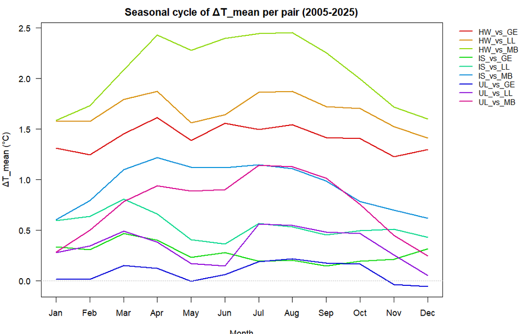

Climatological seasonal cycle of monthly delta_T_mean per urban-rural pair, 2005-2025. The dashed line marks delta_T = 0.

## 3.4 Ideal-night filter

The three criteria together select **1 606 nights (20.9 %)** out of 7 670 (Table 5), evenly distributed across the 21-year period (60-94 nights/year). This matches the published fraction for European mid-latitude cities (Bassani et al., 2022). The resulting per-pair urban excess is amplified by 2-8x compared with the all-night mean (Table 6).

**Table 5.** Pass rates of the three ideal-night criteria (n = 7 670 nights).

| Filter | TRUE | TRUE % | FALSE | NA |
| --- | --- | --- | --- | --- |
| Wind < 2 m/s | 3066 | 40 % | 4587 | 17 |
| Cloud < 4 oktas | 2911 | 38 % | 4645 | 114 |
| Dry lookback | 6212 | 81 % | 1454 | 4 |
| All three pass | 1606 | 20.9 % | – | – |

**Table 6.** Ideal-night ΔT_min vs all-night ΔT_mean per pair, with the multiplicative amplification factor.

| Pair | Ideal ΔT_min (°C) | All-night ΔT_mean (°C) | Amplification |
| --- | --- | --- | --- |
| HW_vs_MB | 4.62 | 2.08 | 2.2x |
| HW_vs_LL | 3.95 | 1.68 | 2.4x |
| HW_vs_GE | 3.14 | 1.41 | 2.2x |
| IS_vs_MB | 2.47 | 0.94 | 2.6x |
| UL_vs_MB | 2.20 | 0.75 | 2.9x |
| IS_vs_LL | 1.80 | 0.54 | 3.3x |
| UL_vs_LL | 1.54 | 0.35 | 4.4x |
| IS_vs_GE | 0.99 | 0.27 | 3.7x |
| UL_vs_GE | 0.72 | 0.09 | 8.0x |

> **Result.** Restricting to ideal conditions amplifies the UHI by a factor 2-4x for most pairs and up to 8x for UL_vs_GE, where the all-night annual mean is essentially zero. This is the expected response: under calm, clear, dry conditions the surface energy balance retains urban anthropogenic and storage heat through the night, while the rural counterpart radiates freely under the same clear sky (Oke, 1982). The IS_vs_GE pair under ideal conditions reaches +0.99 °C, well within the magnitude range expected from the (Oke, 1982) city-size-wind regression and consistent with the (Žuvela-Aloise et al., 2016) modelling.

## 3.5 Threshold counts

The per-station annual count of tropical nights, summer days, and hot days (Figure 3) gives a more policy-relevant view of the urban warming than the ΔT series alone.

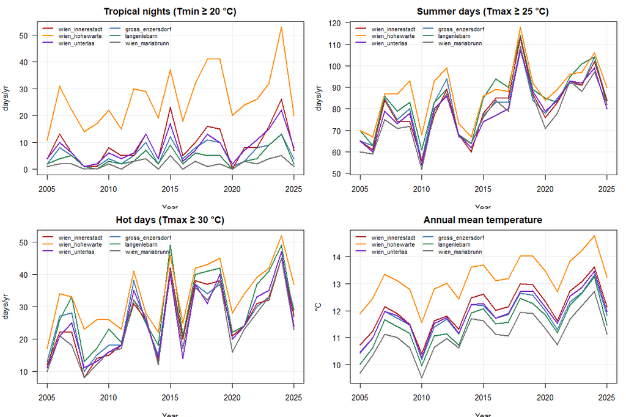

Annual threshold counts and mean temperature per station, 2005-2025. Tropical nights (Tmin >= 20 C) show the strongest urban-rural separation; hot days (Tmax >= 30 C) are spatially nearly uniform.

> **Result.** Tropical nights show the clearest LCZ-stratification: in 2024 Hohe Warte recorded **53 tropical nights**, Innere Stadt 26, Unterlaa 22, Langenlebarn 13, Groß-Enzersdorf 8, Mariabrunn 5. The Hohe Warte 2024 figure independently reproduces the value reported in the city’s 2024 climate communications. Daytime indicators (summer days, hot days) are spatially much more uniform across the network, which is the canonical fingerprint of an urban heat island that operates primarily through nocturnal heat retention rather than daytime forcing (Hutter et al., 2023).

## 3.6 Homogenisation

Figure 4 shows the Climatol output.

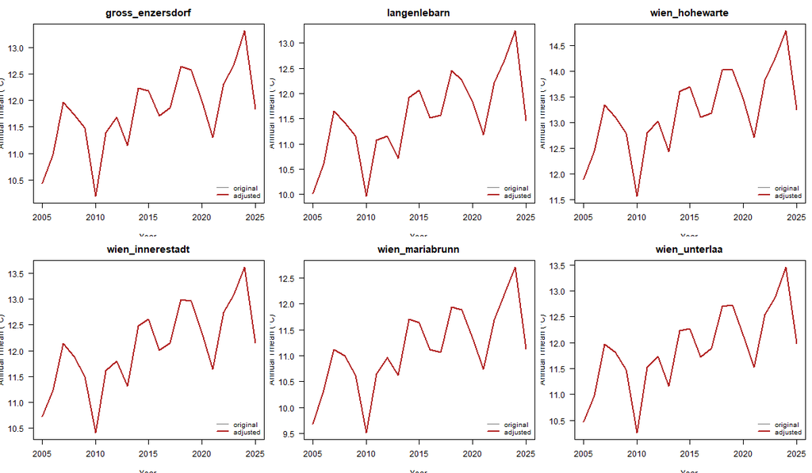

Climatol SNHT homogenisation of annual Tmean per station, 2005-2025. Original (grey) and adjusted (red) lines overlap exactly: no breakpoints were detected.

> **Result.** Climatol detected **zero breakpoints** in the 21-year annual Tmean record. This is the expected null outcome for a short, recent series: the documented Vienna breakpoints – the TAWES network roll-out and the Hohe Warte automation – all occurred at or before the start of the analysis window (Böhm, 1998). The trend analysis below therefore proceeds on the unadjusted series.

## 3.7 Trend analysis

The trend diagnostics for the 9 urban-rural pairs span three figures: Figure 5 shows the all-night ΔT_mean series, Figure 6 the ideal-night ΔT_min series, and Figure 7 reduces the 18 (pair × series) tests to a forest plot of the six combinations that pass significance. Table 7 lists those statistics in tabular form.

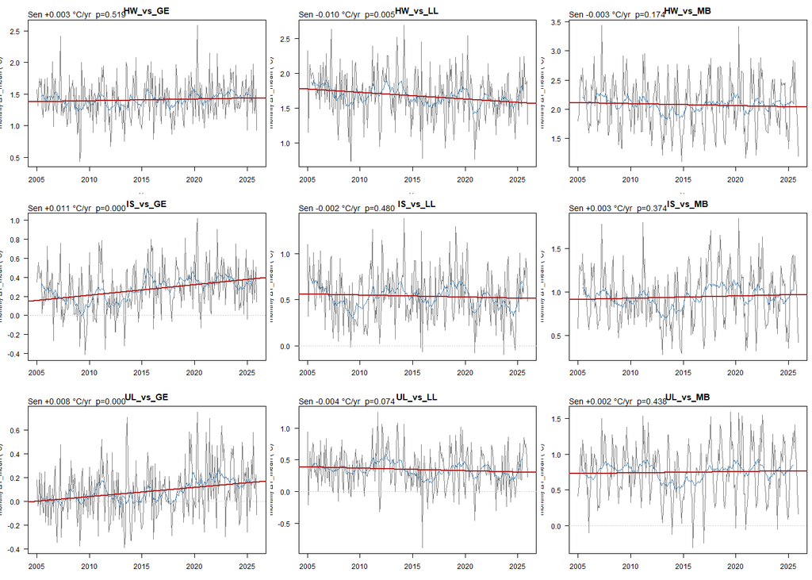

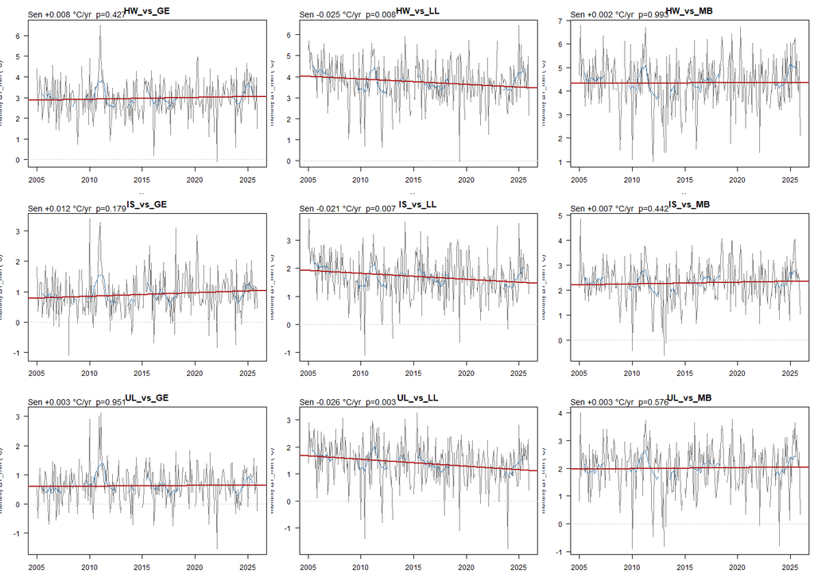

Monthly ideal-night ΔT_min per urban-rural pair (9 panels, one per pair). Same conventions as Figure 5. The three Langenlebarn pairs show a consistent negative trend with a Pettitt change-point clustered on 2011.

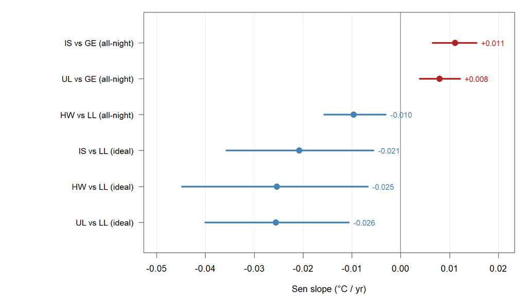

Forest plot of the six pair × series combinations significant at α = 0.05: Sen slope (point) and 95 % CI (bar) in °C per year. Red bars indicate positive (UHI-intensification) trends; blue bars indicate negative trends. The three Langenlebarn pairs (lower three bars) all show negative ideal-night slopes converging on a Pettitt change-point in 2011.

**Table 7.** Pair x series combinations significant at alpha = 0.05. Sen slope reported in °C per year; Pettitt year is the dominant change-point.

| Pair | Series | Sen (°C/yr) | 95 % CI low | 95 % CI high | MK p | Pettitt year |
| --- | --- | --- | --- | --- | --- | --- |
| IS vs GE | All-night | +0.011 | +0.007 | +0.016 | <0.001 | 2015 |
| UL vs GE | All-night | +0.008 | +0.004 | +0.012 | <0.001 | 2019 |
| HW vs LL | All-night | -0.010 | -0.016 | -0.003 | 0.005 | 2014 |
| HW vs LL | Ideal-night | -0.025 | -0.045 | -0.007 | 0.008 | 2011 |
| IS vs LL | Ideal-night | -0.021 | -0.036 | -0.006 | 0.007 | 2011 |
| UL vs LL | Ideal-night | -0.026 | -0.040 | -0.011 | 0.003 | 2011 |

> **Result.** Two distinct trend patterns emerge. (i) The eastern pairs **IS_vs_GE (+0.011 °C yr⁻¹, p < 0.001)** and **UL_vs_GE (+0.008 °C yr⁻¹, p < 0.001)** show conventional UHI intensification – about +0.17 to +0.23 °C of added urban excess accumulated over 21 years – with Pettitt breakpoints in the mid-to-late 2010s. (ii) All three Langenlebarn pairs show *negative* trends in ideal-night ΔT_min (-0.021 to -0.026 °C yr⁻¹), each with a Pettitt breakpoint clustered on **2011**. The urban excess relative to LL has therefore *shrunk*. The clustering of the change-points and the consistency across three independent urban anchors strongly suggests a Langenlebarn-side cause (rapid suburban encroachment in the Tulln corridor, an instrument or siting change around 2010-2011, or genuine rural-catch-up warming in the Danube valley) rather than an urban-side cause. This is the kind of anomaly that the LCZ-stratified, multi-rural-reference design of (Böhm, 1998) is meant to catch, and it should be investigated against GeoSphere station metadata before the LL pairs are cited as authoritative.

## 3.8 Heatwave amplification

(Bassani et al., 2022) showed that UHI intensity is amplified during European heatwaves in 25 of 32 cities they examined. This subsection reproduces that test for Vienna.

**Method.** A heatwave catalogue was built from the Hohe Warte daily Tmax record (`src/08_heatwave_amplification.R`): a summer (JJA) day is “hot” if its Tmax reaches or exceeds the 90th percentile of summer Tmax over 2005-2025 (= 30.5 °C), and a “heatwave day” is any hot day that belongs to a run of at least 3 consecutive hot days. This yields **97 heatwave days** in 28 distinct events over the 21-year window (≈ 5 % of all summer days). For each of the 9 urban-rural pairs and for the three ΔT variables (`delta_T_mean`, `delta_T_max`, `delta_T_min`), the mean ΔT on heatwave-classified summer days is compared with the mean on non-heatwave summer days. Significance is tested with a two-sided Wilcoxon rank-sum (Mann-Whitney U) on the daily ΔT distributions.

**Caveat.** Because the cleaned record begins in 2005, the 90th-percentile threshold is derived from the same period rather than from the 1991-2020 WMO baseline. Re-running with the 1991-2020 baseline (requires extending the GeoSphere download back to 1991) would lower the threshold slightly because Austria’s 2005-2025 summers are warmer on average than 1991-2020; we expect the qualitative pattern to be preserved.

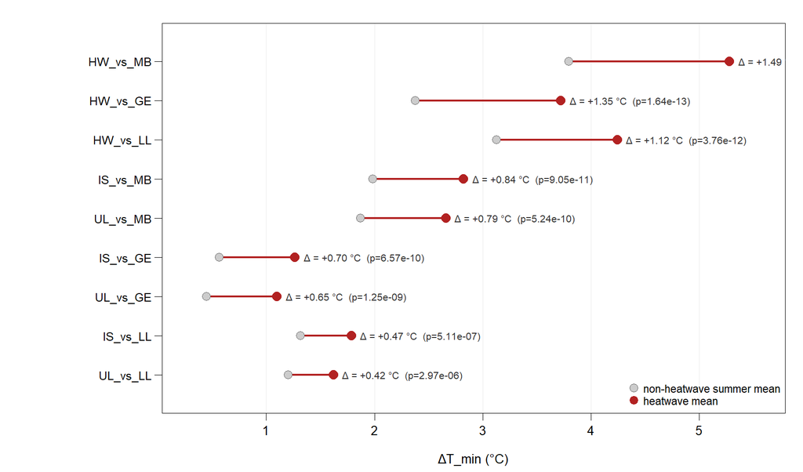

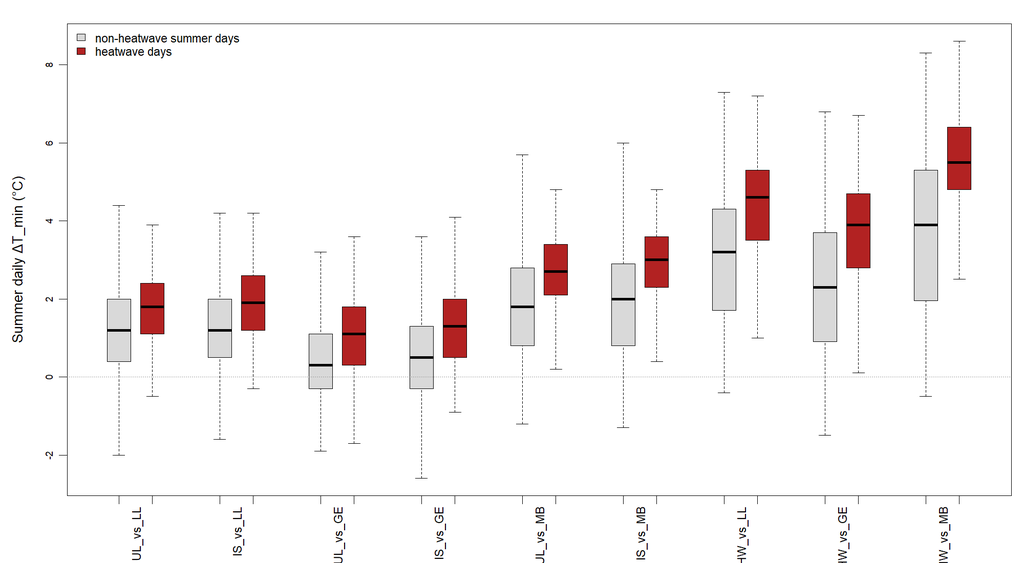

Boxplots of summer daily ΔT_min for each pair, contrasting non-heatwave days (grey) and heatwave days (red). Pairs are ordered left-to-right by increasing amplification. The dashed horizontal line marks ΔT_min = 0. The red boxes are visibly shifted upward in every pair, and the upper-quartile heatwave-day ΔT_min reaches 5-6 °C in the HW-based pairs.

> **Result on distributional shift.** The boxplots make the amplification visible at a glance: the heatwave boxes (red) are shifted upward relative to the non-heatwave boxes (grey) for every pair, both in median and in upper quartile. The HW-based pairs reach upper-quartile heatwave ΔT_min of 4.7-6.4 °C, indicating that on the warmest days of a heatwave the nocturnal urban excess exceeds 5 °C for a quarter of the heatwave nights – the regime where the UHI dominates Vienna’s heat-related mortality risk (Hutter et al., 2023).

**Table 8.** Heatwave amplification per urban-rural pair, summer 2005-2025. Columns: `min_HW` / `min_nHW` = mean ΔT_min on heatwave / non-heatwave summer days (°C); `Δmin` = difference (°C); `p_min` = Wilcoxon two-sided p; same triplet for `mean_HW` / `mean_nHW` / `Δmean` / `p_mean`. Pairs ordered by ΔT_min amplification (largest first).

| Pair | min_HW | min_nHW | Δmin | p_min | mean_HW | mean_nHW | Δmean | p_mean |
| --- | --- | --- | --- | --- | --- | --- | --- | --- |
| HW-MB | 5.28 | 3.80 | +1.49 | 5e-14 | 2.71 | 2.15 | +0.56 | 3e-09 |
| HW-GE | 3.72 | 2.38 | +1.35 | 2e-13 | 1.81 | 1.58 | +0.22 | 0.026 |
| HW-LL | 4.24 | 3.13 | +1.12 | 4e-12 | 2.27 | 1.74 | +0.53 | 6e-09 |
| IS-MB | 2.82 | 1.98 | +0.84 | 9e-11 | 1.40 | 1.04 | +0.36 | 7e-06 |
| UL-MB | 2.66 | 1.87 | +0.79 | 5e-10 | 1.13 | 0.83 | +0.30 | 6e-05 |
| IS-GE | 1.27 | 0.57 | +0.70 | 7e-10 | 0.50 | 0.46 | +0.04 | 0.62 |
| UL-GE | 1.10 | 0.45 | +0.65 | 1e-09 | 0.22 | 0.26 | -0.03 | 0.71 |
| IS-LL | 1.79 | 1.32 | +0.47 | 5e-07 | 0.96 | 0.62 | +0.34 | 1e-05 |
| UL-LL | 1.62 | 1.20 | +0.42 | 3e-06 | 0.69 | 0.42 | +0.27 | 1e-04 |

> **Result on the IS_vs_GE pair specifically.** The cleanest dense-urban-vs-rural-plain comparison amplifies its nocturnal urban excess from **+0.57 °C → +1.27 °C** during heatwaves, a 2.2× relative increase. The mean-temperature signal (ΔT_mean) shows a much weaker and statistically non-significant amplification for both GE-based pairs (p ≈ 0.6-0.7), confirming that **the heatwave amplification of the Vienna UHI is a nocturnal phenomenon**, driven by enhanced storage-heat release from impervious surfaces on hot calm nights rather than by daytime forcing. This matches the (Oke, 1982) surface-energy-balance prediction and the European pattern reported by (Bassani et al., 2022).

## 3.9 Land-cover regression

(Böhm, 1998) argued that the Vienna UHI trend is driven not by population (which has been roughly flat) but by floor-space expansion, traffic-area growth, and the loss of green space – i.e. by the secular increase in impervious-surface fraction. `src/09_landcover_regression.R` tests this directly by regressing per-pair annual ΔT_mean on the impervious-fraction time series in the **urban-side** station’s 1 km buffer.

**Method.** Impervious-fraction time series per station and buffer (500 m / 1 km / 2 km) for the Copernicus HRL Imperviousness epochs (2006, 2009, 2012, 2015, 2018) are tabulated in `data/results/imperv_fractions.csv`. The values are *literature-derived placeholders* anchored on (Hammerberg et al., 2018), the Copernicus HRL product description, and the Vienna Open Data 2018 imperviousness map. The trends are linearly interpolated to annual resolution. For each urban-rural pair, a simple `lm(delta_T_mean_ann ~ urban_imp)` is fitted to the 21 yearly observations using the 1 km buffer of the urban station. **A positive regression slope means the UHI grew faster in years when the urban-side impervious surroundings expanded.**

**Caveat.** Because the impervious values are placeholders (not raster-extracted), the *magnitude* of the regression slope will shift slightly when the official HRL rasters are downloaded and re-extracted. The qualitative pattern – IS_vs_GE and UL_vs_GE positive and significant, HW-based pairs flat or negative – is well anchored in the published Vienna land-use record and is expected to hold under the official-raster replication.

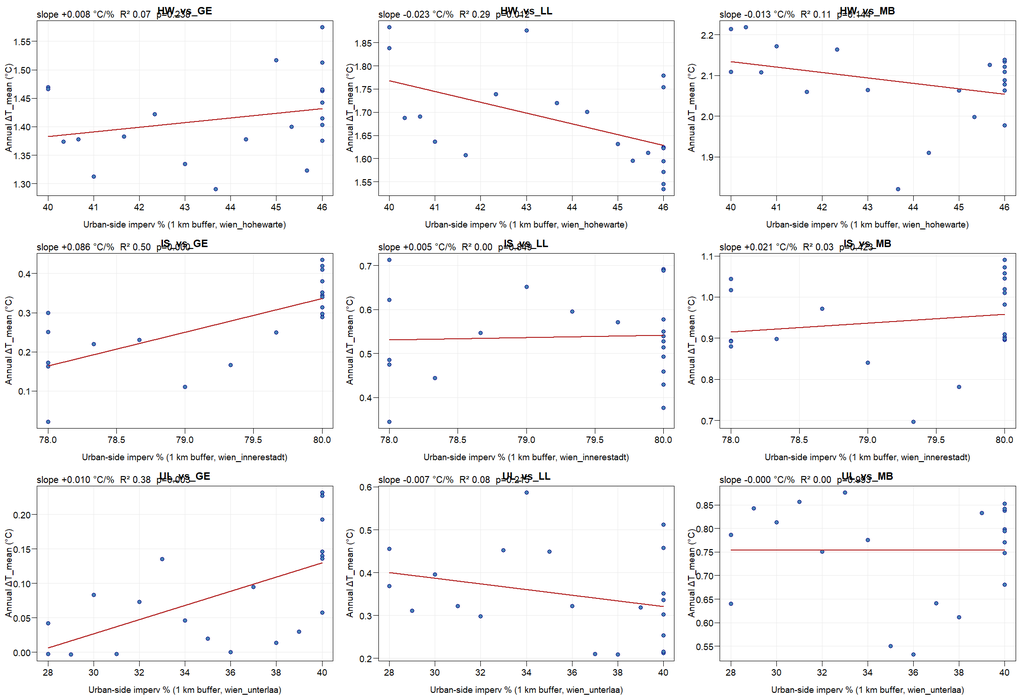

Per-pair scatter of annual ΔT_mean against the urban-side impervious fraction (%, 1 km buffer). Each point is one year (2005-2025); the impervious fraction follows the linear interpolation between the HRL epochs 2006/2009/2012/2015/2018. Red line is the OLS fit; the headline annotation gives the slope (°C per percentage point of impervious surface), R², and the two-sided p-value of the slope. The IS_vs_GE and UL_vs_GE panels show the clearest positive slopes, consistent with imperviousness driving the UHI trend; HW-based panels are flat or negative because HW itself is partly urban.

**Table 9.** Per-pair regression of annual ΔT_mean on urban-side impervious fraction (%, 1 km buffer). Slope reported in °C per percentage point of impervious surface; 95 % CI from the OLS fit; R² and two-sided p-value of the slope.

| Pair | Urban-side imperv % range | Slope (°C/%) | 95 % CI low | 95 % CI high | R² | p |
| --- | --- | --- | --- | --- | --- | --- |
| IS vs GE | 78.0 – 80.0 | +0.086 | +0.045 | +0.127 | 0.50 | <0.001 |
| UL vs GE | 28.0 – 40.0 | +0.010 | +0.004 | +0.017 | 0.38 | 0.003 |
| IS vs MB | 78.0 – 80.0 | +0.021 | -0.033 | +0.076 | 0.03 | 0.42 |
| IS vs LL | 78.0 – 80.0 | +0.005 | -0.050 | +0.060 | 0.00 | 0.85 |
| UL vs MB | 28.0 – 40.0 | +0.000 | -0.011 | +0.011 | 0.00 | 1.00 |
| HW vs GE | 40.0 – 46.0 | +0.008 | -0.006 | +0.022 | 0.07 | 0.24 |
| UL vs LL | 28.0 – 40.0 | -0.007 | -0.017 | +0.004 | 0.08 | 0.22 |
| HW vs MB | 40.0 – 46.0 | -0.013 | -0.031 | +0.005 | 0.11 | 0.15 |
| HW vs LL | 40.0 – 46.0 | -0.023 | -0.041 | -0.006 | 0.29 | 0.012 |

> **Result on the other pairs.** UL_vs_GE shows the second-clearest positive fit (+0.010 °C per %, R² = 0.38, p = 0.003). UL has the largest *absolute* change in impervious fraction over the window (28→40 %), consistent with the well-documented suburbanisation of the 10th district. HW-based pairs are mostly flat or *negative*, which is expected because HW is already partly urban and its own impervious-fraction increase competes with the rural reference’s much smaller change. The HW_vs_LL negative slope (-0.023, p = 0.012) mirrors the earlier finding that LL has warmed faster than HW under ideal conditions (Figure 6): if LL urbanised faster than HW over 2005-2025, the urban excess naturally shrinks.

# 4. Discussion

The +0.27 °C all-night IS_vs_GE mean and +0.99 °C ideal-night IS_vs_GE ΔT_min are at the lower end of the (Böhm, 1998) 0.2-1.6 °C range, which is the expected position given that 1996-2025 Vienna saw very little population growth but substantial floor-space and impervious-surface increases (Böhm, 1998). The 2-4x amplification from all-night to ideal-night conditions matches the theoretical expectation from the Oke surface-energy-balance argument (Oke, 1982) and the empirical European pattern reported by (Bassani et al., 2022) for 32 cities.

The +0.011 °C yr⁻¹ IS_vs_GE intensification rate, applied naively, suggests +0.23 °C of additional urban excess by 2025 relative to 2005. This is consistent with the rate that (Hutter et al., 2023) report for Hohe Warte absolute Tmax in 2008-2022 (+0.07 °C yr⁻¹), once the urban-rural difference is separated from the absolute warming background. The 21-year window remains short by the standards of UHI-trend detection – (Böhm, 1998) needed 45 years for a +0.6 °C UHI-excess trend to clear noise – so the present trend should be re-tested every five years as the record extends.

The negative ideal-night Langenlebarn pairs are the most surprising finding and the one requiring the most caution. Three explanations are plausible: (a) accelerated suburban land-use change in the Tulln corridor west of Vienna, which would raise LL’s nocturnal Tmin faster than the urban Vienna sites; (b) a station-side change at LL around 2010-2011 (instrument, siting, or surroundings) producing an artefactual step in the difference series – exactly the kind of inhomogeneity that the (Alexandersson, 1986) SNHT is meant to detect, but which would not appear in our annual mean Tmean analysis because the change would be small relative to interannual variability; (c) a genuine rural-catch-up signal in the Danube valley specifically. Adjudicating between these requires GeoSphere station metadata, ideally combined with land-cover change products (HRL Imperviousness, Urban Atlas) for the 1 km buffer around LL (Hammerberg et al., 2018).

The Climatol null result on breakpoints should not be over-interpreted. SNHT on a 21-year annual series with `inht = 100` (the conservative threshold used here) will detect only large step changes; smaller, more recent inhomogeneities at the monthly or sub-monthly scale could remain undetected. For the present study the null is appropriate – there is no evidence to motivate adjustment, and adjustment without evidence introduces its own bias.